# Homework 5: Classification

STAT656

# Digits data

In this assignment, we are going to revisit the digits data example from class. For more information about this, see the posted lectures videos (Parts 1 through 5) and marsAndFDA2.Rmd.

Following the discussion in class, let’s look at hand draw 5s and 8s

# Packages and helper function

```r
require(dplyr)
require(earth)     # fit MARS models
require(caret)     # automating the tuning process
require(vip)       # variable importance
require(glmnet)
```

```r
require(lattice)   # to plot digits
require(gridExtra) # to plot digits (grid.arrange)
require(pROC)
require(neuralnet)
require(mda)
```

You will also need the ‘mda’ package for the MARS model.

Also, here is a helper function for plotting the vectorized digit back into an image:

```r
plotDigit = function(x) {
  cols = gray.colors(100, start = 0, end = 1, rev=TRUE)
  matObj = matrix(x,nrow=28)[,28:1]
  mode(matObj) = 'numeric'
  levelplot(matObj,col.regions=cols, xlab = '', ylab = '')
}
```

Let’s read in the data set.

```r
training = read.csv('digits.csv')
Y = make.names(training$label)
X = select(training, -label) %>% filter( Y == 'X5'| Y == 'X8')
Y = as.factor(Y[Y == 'X5' | Y == 'X8'])

set.seed(1)
trainSplit = createDataPartition(y = Y, p = 0.8, list = FALSE)

Ytrain = Y[trainSplit]
Xtrain = X[trainSplit,]
XtrainMat = as.matrix(Xtrain)
Ytest  = Y[-trainSplit]
Xtest  = X[-trainSplit,]
XtestMat = as.matrix(Xtest)
```

Here are some example plots:

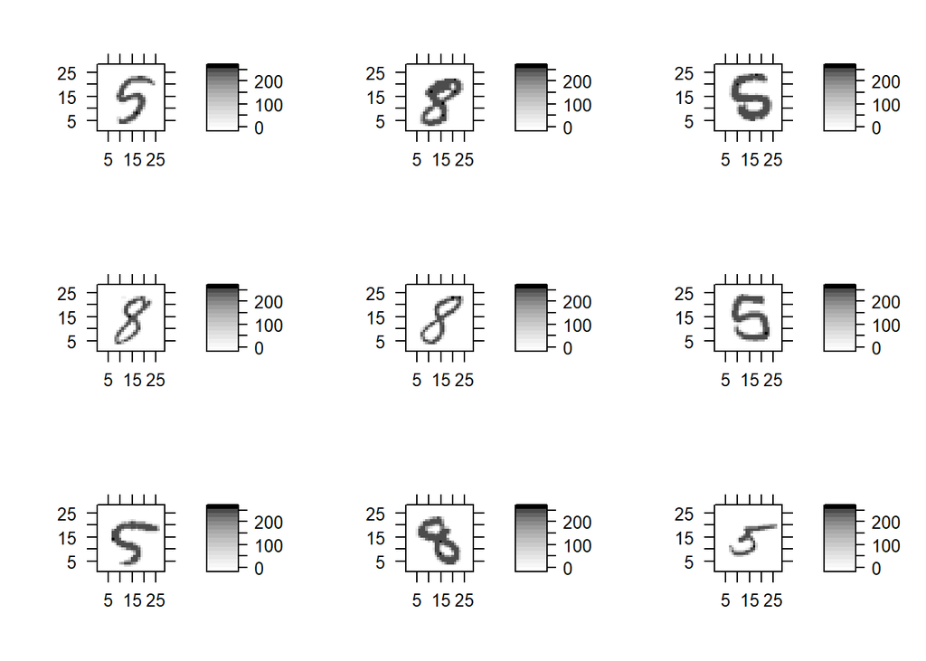

```r
plotObj = vector('list',9)
for(j in 1:9){
    plotObj[[j]] = plotDigit(X[j,])
}
do.call(grid.arrange, plotObj)
```

# Problem 1 (30 pts). Logistic elastic net.

Let’s look at a fitting the logistic elastic net

```r
set.seed(1)
K            = 5
trainControl = trainControl(method = "cv", number = K)
tuneGrid     = expand.grid('alpha'=c(.5, 1),'lambda' = seq(0.0001, .01, length.out = 10))

elasticOut = train(
  x = Xtrain,
  y = Ytrain,
  method = "glmnet",
  trControl = trainControl,
  tuneGrid = tuneGrid
)

elasticOut$bestTune
```

```
##   alpha lambda
## 6   0.5 0.0056
```

Using these selected tuning parameters, let’s get some predictions on the test digits data

```r
glmnetOut         = glmnet(x = XtrainMat, y = relevel(Ytrain, ref = 'X8'),
                           alpha = elasticOut$bestTune$alpha, family = 'binomial')
probHatTestGlmnet = predict(glmnetOut, XtestMat, s=elasticOut$bestTune$lambda, type = 'response')
YhatTestGlmnet    = ifelse(
  probHatTestGlmnet > 0.5,
  "X5",
  "X8"
)

confusionMatrix(
  data = factor(YhatTestGlmnet, levels = c("X5", "X8")),
  reference = factor(Ytest, levels = c("X5", "X8")),
  positive = "X5"
)
```

```
## Confusion Matrix and Statistics
##
##           Reference
## Prediction  X5  X8
##         X5 735  25
##         X8  24 787
##
##                Accuracy : 0.9688
##                  95% CI : (0.959, 0.9768)
##     No Information Rate : 0.5169
##     P-Value [Acc > NIR] : <2e-16
##
##                   Kappa : 0.9376
##
##  Mcnemar's Test P-Value : 1
##
##             Sensitivity : 0.9684
##             Specificity : 0.9692
##          Pos Pred Value : 0.9671
##          Neg Pred Value : 0.9704
##              Prevalence : 0.4831
##          Detection Rate : 0.4679
##    Detection Prevalence : 0.4838
##       Balanced Accuracy : 0.9688
##
##        'Positive' Class : X5
##
```

We can look at the active set as well. For this assignment, just to make the picture easier to explain, we will use a threshold of 0.005 instead of something near 0.

```r
betaHat = coef(glmnetOut, s=elasticOut$bestTune$lambda)
Sglmnet = abs(betaHat[-1]) > .005
```

By looking at the estimated coefficients, we can gain insight into which pixels seem to be associated with each digit. Also, as the features are standardized, we can use the coefficient magnitude to rank the features in importance

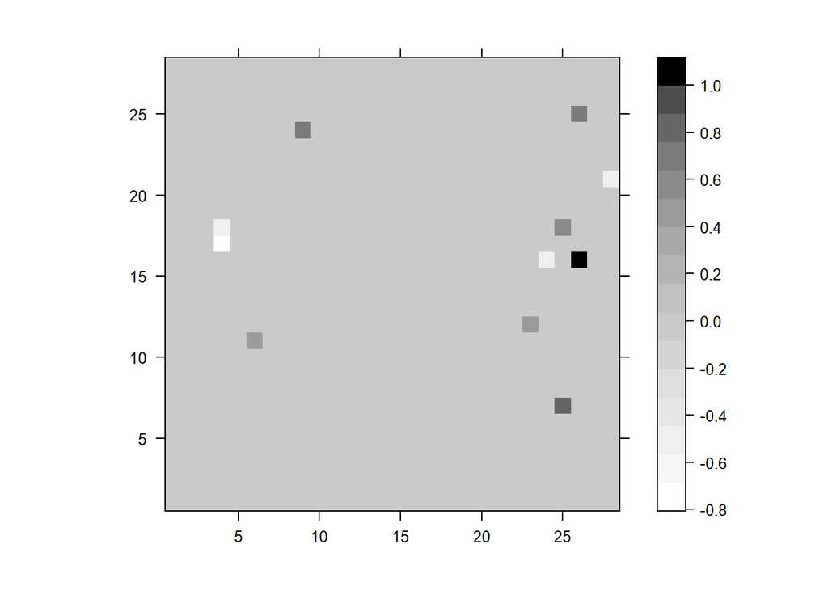

```r
importantGlmnet = betaHat[-1][Sglmnet]

importantDigit = rep(0,28**2)
importantDigit[Sglmnet] = importantGlmnet/max(abs(importantGlmnet))

plotDigit(importantDigit)
```

Let’s compare these important pixels to a few digits from the training data

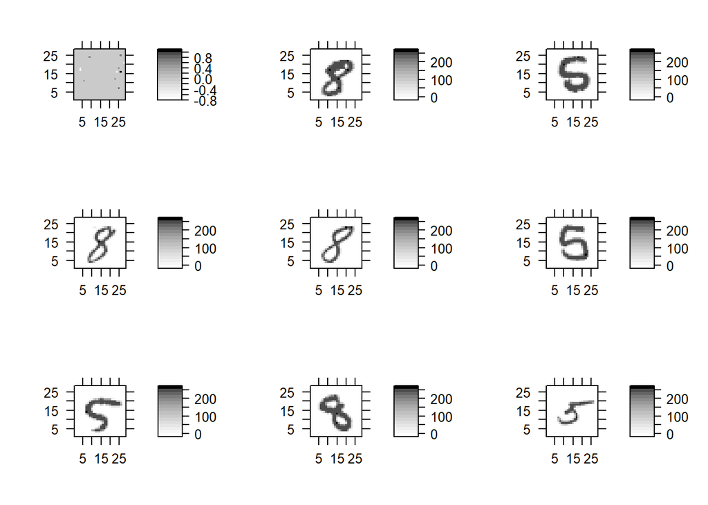

```r
plotObj = vector('list',9)
plotObj[[1]] = plotDigit(importantDigit)
for(j in 2:9){
  plotObj[[j]] = plotDigit(X[j,])
}
do.call(grid.arrange, plotObj )
```

#### Answer 1.3

Describe this image by identifying pixels that seem to be positively associated with Y = ‘X5’ and positively associated with Y = ‘X8’.

The elastic net model identifies important pixels through the magnitude and sign of their estimated coefficients. Because digit 5 is treated as the positive class, positive coefficients increase the predicted log-odds of digit 5, while negative coefficients increase the relative evidence for digit 8. Coefficients close to zero contribute relatively little to the prediction, and coefficients equal to zero have been excluded by regularization. The important pixels represent locations where the shapes of digits 5 and 8 differ.

# Problem 2 (40 points). MARS applied to classification

### Problem 2.1

Let’s look at applying MARS to digits using the *caret* package

```r
fdaOut = train(x = Xtrain,
                y = Ytrain,
                method = 'fda',
                metric = 'Accuracy',
                tuneGrid = expand.grid(degree = 1:3, nprune = c(10,20,50,100)),
                trControl = trainControl(method='CV',number = K, classProbs = TRUE))
fdaOut
```

```
## Flexible Discriminant Analysis
##
## 6287 samples
##  784 predictor
##    2 classes: 'X5', 'X8'
##
## No pre-processing
## Resampling: Cross-Validated (5 fold)
## Summary of sample sizes: 5029, 5030, 5030, 5030, 5029
## Resampling results across tuning parameters:
##
##   degree  nprune  Accuracy   Kappa
##   1        10     0.9107646  0.8216415
##   1        20     0.9163309  0.8328303
##   1        50     0.9163309  0.8328303
##   1       100     0.9163309  0.8328303
##   2        10     0.9392373  0.8782663
##   2        20     0.9506886  0.9012832
##   2        50     0.9535514  0.9070269
##   2       100     0.9535514  0.9070269
##   3        10     0.9408283  0.8815482
##   3        20     0.9540310  0.9079952
##   3        50     0.9610302  0.9220029
##   3       100     0.9610302  0.9220029
##
## Accuracy was used to select the optimal model using the largest value.
## The final values used for the model were degree = 3 and nprune = 50.
```

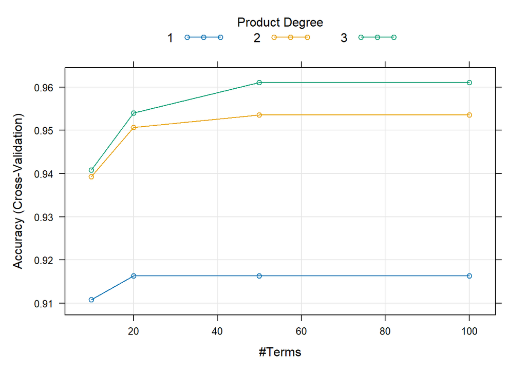

```r
plot(fdaOut)
```

```r
fdaOut$bestTune
```

```
##    degree nprune
## 11      3     50
```

#### Answer 2.1

What values of degree and nprune are selected by maximizing CV accuracy?

The five-fold cross-validation selected a MARS/FDA model with degree = 3 and nprune = 50. The degree parameter allows interactions among up to three predictors, while nprune controls the maximum number of terms retained in the model.

The cross-validation plot shows that degree 3 consistently achieves higher accuracy than degrees 1 and 2. Accuracy improves as the number of terms increases from 10 to 50, but there is little additional improvement beyond 50 terms. The selected model achieves approximately 96.1% cross-validation accuracy, suggesting that nonlinear interactions among pixels are useful for distinguishing handwritten digits 5 and 8.

### Problem 2.2

```r
# Predict classes on the test set
YhatTestFDA = predict(
  fdaOut$finalModel,
  Xtest,
  type = "class"
)

# Calculate confusion matrix
confusionMatrix(
  data = factor(YhatTestFDA, levels = c("X5", "X8")),
  reference = factor(Ytest, levels = c("X5", "X8")),
  positive = "X5"
)
```

```
## Confusion Matrix and Statistics
##
##           Reference
## Prediction  X5  X8
##         X5 738  28
##         X8  21 784
##
##                Accuracy : 0.9688
##                  95% CI : (0.959, 0.9768)
##     No Information Rate : 0.5169
##     P-Value [Acc > NIR] : <2e-16
##
##                   Kappa : 0.9376
##
##  Mcnemar's Test P-Value : 0.3914
##
##             Sensitivity : 0.9723
##             Specificity : 0.9655
##          Pos Pred Value : 0.9634
##          Neg Pred Value : 0.9739
##              Prevalence : 0.4831
##          Detection Rate : 0.4698
##    Detection Prevalence : 0.4876
##       Balanced Accuracy : 0.9689
##
##        'Positive' Class : X5
##
```

We can also get the feature importance out

```r
fdaVip = vip(fdaOut,num_features = 40, bar = FALSE, metric = "Accuracy")
```

[figure not shown]

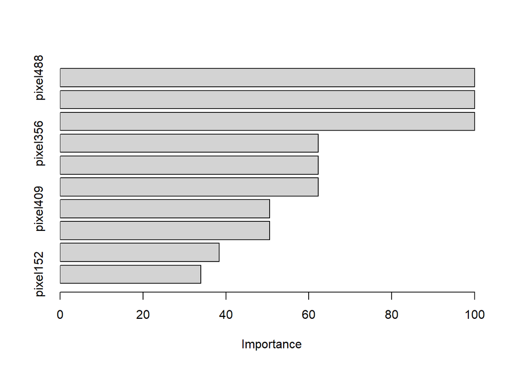

```r
plot(fdaVip)
```

#### Answer 2.2

Which pixel is the most important for discriminating between 5 and 8? How could you go about getting a general idea if that pixel is associated with the class ‘5’ or ‘8’? Which do you conclude?

```r
head(coef(fdaOut$finalModel))
```

```
##                                        [,1]
## (Intercept)                    2.074622e+00
## h(pixel488-43)                 2.289183e-03
## h(43-pixel488)                -2.146776e-02
## h(pixel486-39)*h(43-pixel488)  1.572652e-04
## h(39-pixel486)*h(43-pixel488) -5.501252e-04
## h(79-pixel407)*h(pixel488-43) -3.317332e-05
```

```r
tapply(Xtrain$pixel488, Ytrain, mean)
```

```
##        X5        X8
##  27.47036 168.33036
```

Pixel 488 is among the most important pixels identified by the FDA model. To determine which digit it is associated with, I compared its average intensity between the two classes. The mean intensity is approximately 27.47 for digit 5 and 168.33 for digit 8. Therefore, higher intensity at pixel 488 is strongly associated with digit 8 in the training data.

### Problem 2.3

Let’s look at the importance object we computed with *vip*

```r
important = as.character(
  fdaVip$data$Variable[fdaVip$data$Importance > 1e-16]
)

importantVal = fdaVip$data$Importance[
  fdaVip$data$Importance > 1e-16
]

# Extract pixel number and add 1 for the feature index
importantIndex = as.numeric(
  sub("pixel", "", important)
) + 1

importantDigit = rep(0,28**2)
importantDigit[importantIndex] = importantVal/max(importantVal)
```

[figure not shown]

```r
plotDigit(importantDigit)
```

Again, comparing the importance plot to some digits from the training data

[figure not shown]

```r
plotObj = vector('list',9)
plotObj[[1]] = plotDigit(importantDigit)
for(j in 2:9){
  plotObj[[j]] = plotDigit(X[j,])
}
do.call(grid.arrange, plotObj )
```

#### Answer 2.3.

Why do you think these pixels would be important for discriminating between Y = ‘X5’ and Y = ‘X8’.

These pixels are likely important because handwritten 5s and 8s have different stroke patterns. Digit 8 typically contains two connected loops, while digit 5 has a different upper and middle structure. Pixels located in regions where these shapes differ can provide useful information for classification. For example, pixel488 has a much higher average intensity for digit 8, suggesting that this location is more frequently occupied by a stroke in handwritten 8s than in 5s.

# Predictions on the test set

Remember that when you see the word ‘posterior’ when looking at a classification method, you should think ‘probability estimate’

```r
probHatTestFDA = predict(fdaOut$finalModel, Xtest, type='posterior')
YhatTestFDA    =  factor(
  ifelse(probHatTestFDA[, "X5"] > 0.5, "X5", "X8"),
  levels = levels(Ytest)
)
```

The confusion matrices

```r
#### Answer 2.3.2
confusionMatrix(
  data = factor(YhatTestGlmnet, levels = levels(Ytest)),
  reference = Ytest,
  positive = "X5"
)
```

```
## Confusion Matrix and Statistics
##
##           Reference
## Prediction  X5  X8
##         X5 735  25
##         X8  24 787
##
##                Accuracy : 0.9688
##                  95% CI : (0.959, 0.9768)
##     No Information Rate : 0.5169
##     P-Value [Acc > NIR] : <2e-16
##
##                   Kappa : 0.9376
##
##  Mcnemar's Test P-Value : 1
##
##             Sensitivity : 0.9684
##             Specificity : 0.9692
##          Pos Pred Value : 0.9671
##          Neg Pred Value : 0.9704
##              Prevalence : 0.4831
##          Detection Rate : 0.4679
##    Detection Prevalence : 0.4838
##       Balanced Accuracy : 0.9688
##
##        'Positive' Class : X5
##
```

```r
#### Answer 2.3.3
confusionMatrix(
  data = YhatTestFDA,
  reference = Ytest,
  positive = "X5"
)
```

```
## Confusion Matrix and Statistics
##
##           Reference
## Prediction  X5  X8
##         X5 738  28
##         X8  21 784
##
##                Accuracy : 0.9688
##                  95% CI : (0.959, 0.9768)
##     No Information Rate : 0.5169
##     P-Value [Acc > NIR] : <2e-16
##
##                   Kappa : 0.9376
##
##  Mcnemar's Test P-Value : 0.3914
##
##             Sensitivity : 0.9723
##             Specificity : 0.9655
##          Pos Pred Value : 0.9634
##          Neg Pred Value : 0.9739
##              Prevalence : 0.4831
##          Detection Rate : 0.4698
##    Detection Prevalence : 0.4876
##       Balanced Accuracy : 0.9689
##
##        'Positive' Class : X5
##
```

#### Answer 2.4.

Which method has the highest sensitivity and what is that sensitivity?

MARS/FDA has the highest sensitivity of 0.9723 (97.23%), compared with 0.9684 (96.84%) for logistic elastic net. Therefore, MARS/FDA performs slightly better at correctly identifying handwritten 5s.

#### Answer 2.5.

Which method has the highest specificity and what is that specificity?

Logistic elastic net has the highest specificity of 0.9692 (96.92%), compared with 0.9655 (96.55%) for MARS/FDA. Therefore, logistic elastic net performs slightly better at correctly identifying handwritten 8s.

#### Answer 2.6.

Which method has the highest precision and what is that precision?

Logistic elastic net has the highest precision of 0.9671 (96.71%), compared with 0.9634 (96.34%) for MARS/FDA. Therefore, logistic elastic net is slightly more precise when predicting handwritten 5s.

# ROC curves

Let’s directly compare the ROC curves. The *roc* function expects the probability estimates to be vectors and right now the glmnet probability estimates are in a $n_test$ by 1 matrix. We can fix that:

```r
probHatTestGlmnet = as.numeric(probHatTestGlmnet)
```

```r
rocOutGlmnet = roc(response = Ytest, probHatTestGlmnet)
```

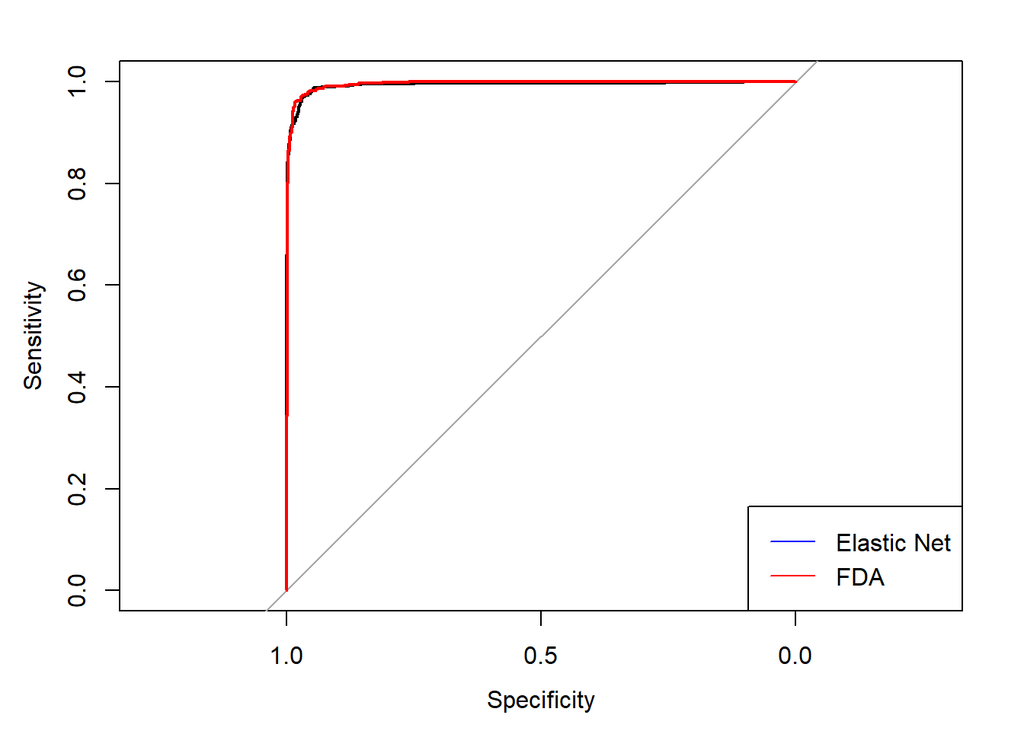

```r
plot(rocOutGlmnet)
rocOutFDA = roc(response = Ytest, probHatTestFDA[,1])
plot(rocOutFDA, col = 'red', add = TRUE)

legend(
  "bottomright",
  legend = c("Elastic Net", "FDA"),
  col = c("blue", "red"),
  lty = 1
)
```

```r
auc(rocOutGlmnet)
```

```
## Area under the curve: 0.9932
```

```r
auc(rocOutFDA)
```

```
## Area under the curve: 0.9954
```

#### Answer 2.7.

Which method has the highest AUC?

```r
#### Answer 2.7.1
auc(rocOutGlmnet)
```

```
## Area under the curve: 0.9932
```

```r
#### Answer 2.7.2
auc(rocOutFDA)
```

```
## Area under the curve: 0.9954
```

The FDA model achieves a slightly higher test AUC (0.9954) than the elastic net model (0.9932). This indicates that FDA has slightly better overall discrimination between digits 5 and 8 across classification thresholds. Although both models have approximately the same test accuracy at the 0.5 threshold, FDA performs marginally better when considering the full ROC curve.

# Problem 3. (30 pts) Neural networks

### Problem 3.1

Let’s fit a simple neural network to these data as well

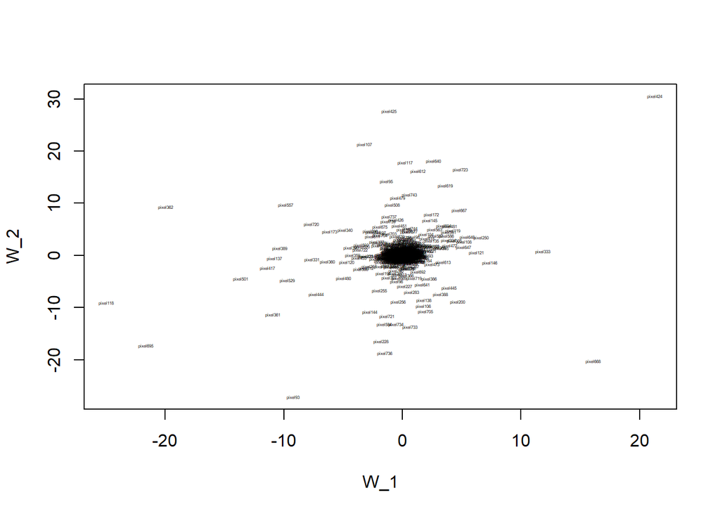

```r
set.seed(1)
nnOut = neuralnet(Ytrain~.,data=Xtrain,
                  hidden=2, rep = 3,
                  err.fct = 'ce', linear.output = FALSE)

Wrep1 = nnOut$weights[[1]][[1]]
Wrep2 = nnOut$weights[[2]][[1]]
Wrep3 = nnOut$weights[[3]][[1]]
W = (Wrep1 + Wrep2 + Wrep3)/3

plot(W[-1,],type='n',xlab='W_1',ylab='W_2')
text(W[-1,],names(X),cex=.25)
```

#### Answer 3.1

```r
head(
  sort(abs(W[-1, 1]), decreasing = TRUE),
  10
)
```

```
##  [1] 24.99671 21.66067 21.26973 19.96185 16.08410 13.65557 11.82989 11.40472
##  [9] 10.95789 10.82267
```

```r
head(
  sort(abs(W[-1, 2]), decreasing = TRUE),
  10
)
```

```
##  [1] 30.54115 27.66443 27.15310 21.24225 20.35071 18.74767 18.09019 17.82976
##  [9] 17.35683 16.50170
```

For the first hidden unit (W1), pixels 118, 424, and 666 appear among those with the most extreme weights. For the second hidden unit (W2), pixels 93, 424, 425, and 666 appear particularly influential. Large absolute weights indicate pixels that strongly affect the corresponding hidden unit, while the sign determines the direction of that effect.

Because the weights are averaged across three neural network repetitions, their interpretation should be treated cautiously. Hidden units can represent similar patterns with different ordering across training runs, so averaging corresponding weights does not necessarily preserve their original meaning.

### Problem 3.2

We will get predictions with the neural network model. We will average the probability estimates from each of the three model fits (from 3 different random starting values. Remember: the solution you get with neural networks depends on where you started)

```r
pHatNN1 = predict(nnOut, Xtest, rep = 1)
pHatNN2 = predict(nnOut, Xtest, rep = 2)
pHatNN3 = predict(nnOut, Xtest, rep = 3)

pHatNN  = (pHatNN1 + pHatNN2 + pHatNN3)/3

YhatTestNN    = ifelse(pHatNN[,1] > 0.5, 'X5', 'X8')

table(YhatTestNN, Ytest)
```

```
##           Ytest
## YhatTestNN  X5  X8
##         X5 693  42
##         X8  66 770
```

#### Answer 3.2

Neural network performance may be improved by adjusting the number of hidden units, experimenting with different network architectures, normalizing the input features, and tuning training parameters. Increasing the number of hidden units may allow the network to capture more complex nonlinear relationships, although it can also increase overfitting. Cross-validation or a separate validation set should be used to select the architecture before evaluating the final model on the test set.

# Extra credit (10 pts)

Attempt one of the strategies you suggested in the previous answer. Report the new test confusion matric. Did it improve the test accuracy?

## Increase hidden neurons from 2 to 10

```r
set.seed(1)

nnImproved = neuralnet(
  Ytrain ~ .,
  data = Xtrain,
  hidden = 10,
  rep = 3,
  err.fct = "ce",
  linear.output = FALSE
)
```

## Generate test predictions

```r
pHatImproved1 = predict(nnImproved, Xtest, rep = 1)
pHatImproved2 = predict(nnImproved, Xtest, rep = 2)
pHatImproved3 = predict(nnImproved, Xtest, rep = 3)

pHatImproved = (
  pHatImproved1 +
  pHatImproved2 +
  pHatImproved3
) / 3

YhatTestImproved = ifelse(
  pHatImproved[, 1] > 0.5,
  "X5",
  "X8"
)
```

## Generate the new confusion matrix

```r
# New confusion matrix
table(YhatTestImproved, Ytest)
```

```
##                 Ytest
## YhatTestImproved  X5  X8
##               X5 727  38
##               X8  32 774
```

```r
# Calculate test accuracy
improvedAccuracy = mean(YhatTestImproved == Ytest)

# Original neural network accuracy
originalAccuracy = mean(YhatTestNN == Ytest)

# Compare
data.frame(
  Model = c("Original NN (2 units)", "Improved NN (10 units)"),
  Accuracy = c(originalAccuracy, improvedAccuracy)
)
```

```
##                    Model  Accuracy
## 1  Original NN (2 units) 0.9312540
## 2 Improved NN (10 units) 0.9554424
```

I increased the number of hidden units from 2 to 10 to investigate whether a larger neural network could improve classification performance. The original network achieved 93.13% test accuracy, while the modified network achieved 95.54%, an improvement of approximately 2.42 percentage points.

The number of misclassified observations decreased from 108 to 70. This suggests that the larger network was better able to capture useful patterns in this experiment. However, additional validation would be necessary to determine whether this improvement generalizes reliably, since increasing model complexity can also increase the risk of overfitting.